# Sprint 0: Experimenting with representation

Mike Johnson

2021-02-24

# Problem/Background

Three tenets of `hy_features` are:

- a catchment realization must be able to perform the functions of a flowpath and a catchment area.
- to support multiple scale models and data, any catchment realization may be composed of a network of other catchment realizations.
- Catchment and nexus provide identity and topology. They do not have attributes or geometry.

Thus, we *need* geometry to inform processing, and we need that geometry to associate flow paths and catchment but be used intercahangbly.

We have 2 distinct files with a shared ID (comid):

```r
source('../R/prep_flownetwork.R')

og_cat <- read_sf("../data/huc1805000502-catchment.gpkg") %>%
   dplyr::select(comid = FEATUREID)

og_fl = read_sf("../data/huc1805000502-flowlines.gpkg") %>%
  prep_flownetwork(og_cat)
```

Lets create a single object that contains both “realizations” is a single go:

```r
source("../R/toy_functions.R")

hy = make_hy(og_fl, og_cat)
head(hy)
```

```
## Simple feature collection with 6 features and 9 fields
## Active geometry column: cat_geom
## geometry type:  MULTIPOLYGON
## dimension:      XY
## bbox:           xmin: -2304618 ymin: 2001005 xmax: -2291595 ymax: 2019405
## CRS:            unknown
## # A tibble: 6 x 11
##    comid                  cat_geom fromCOMID tonode fromnode streamorde
##    <int>        <MULTIPOLYGON [m]> <json>     <dbl>    <dbl>      <int>
## 1 5.33e6 (((-2298945 2010285, -22… [5329357… 1.00e7 10016176          3
## 2 5.33e6 (((-2293875 2001105, -22… ["NA"]  … 1.00e7 10099101          1
## 3 5.33e6 (((-2303625 2016765, -23… ["NA"]  … 1.00e7 10099067          1
## 4 5.33e6 (((-2292915 2009415, -22… [5329345… 1.00e7 10016174          2
## 5 5.33e6 (((-2296875 2010015, -22… ["NA"]  … 1.00e7 10099075          1
## 6 5.33e6 (((-2296755 2012955, -22… ["NA"]  … 1.00e7 10099071          1
## # … with 5 more variables: levelpathi <dbl>, hydroseq <dbl>,
## #   fl_geom <MULTILINESTRING [m]>, toCOMID <int>, lengthkm <dbl>
```

Looking at the header of the print, we see that the ‘active’ geometry column is called `cat_geom`. Thus, if we plot, we get:

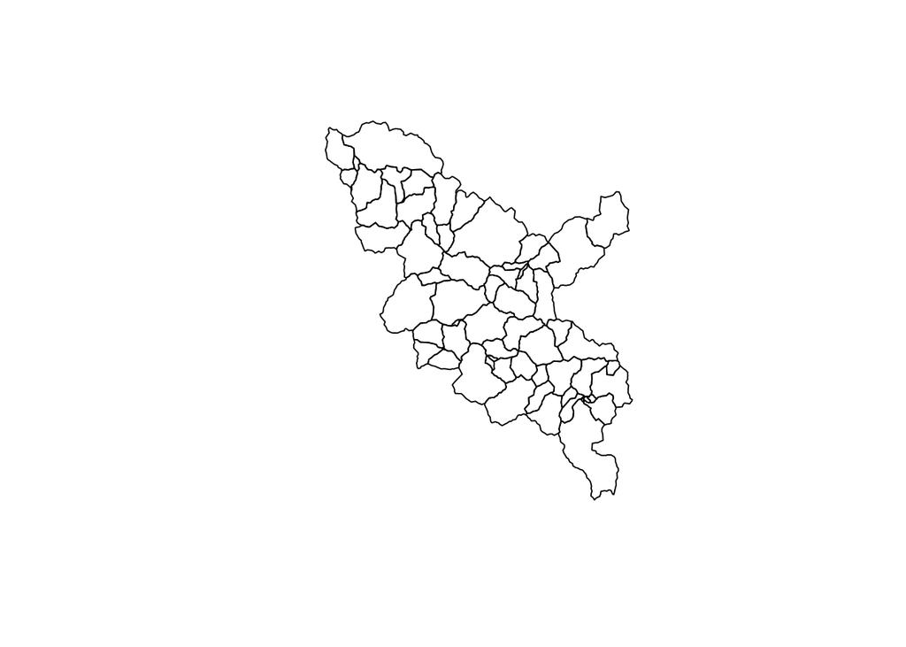

```r
plot(st_geometry(hy))
```

But, often we want/need the flowpath represneation! So lets “activate” the flow path:

```r
hy = activate(hy, "fl")
head(hy)
```

```
## Simple feature collection with 6 features and 9 fields
## Active geometry column: fl_geom
## geometry type:  MULTILINESTRING
## dimension:      XY
## bbox:           xmin: -2304252 ymin: 2001628 xmax: -2291909 ymax: 2018649
## CRS:            unknown
## # A tibble: 6 x 11
##    comid                  cat_geom fromCOMID tonode fromnode streamorde
##    <int>        <MULTIPOLYGON [m]> <json>     <dbl>    <dbl>      <int>
## 1 5.33e6 (((-2298945 2010285, -22… [5329357… 1.00e7 10016176          3
## 2 5.33e6 (((-2293875 2001105, -22… ["NA"]  … 1.00e7 10099101          1
## 3 5.33e6 (((-2303625 2016765, -23… ["NA"]  … 1.00e7 10099067          1
## 4 5.33e6 (((-2292915 2009415, -22… [5329345… 1.00e7 10016174          2
## 5 5.33e6 (((-2296875 2010015, -22… ["NA"]  … 1.00e7 10099075          1
## 6 5.33e6 (((-2296755 2012955, -22… ["NA"]  … 1.00e7 10099071          1
## # … with 5 more variables: levelpathi <dbl>, hydroseq <dbl>,
## #   fl_geom <MULTILINESTRING [m]>, toCOMID <int>, lengthkm <dbl>
```

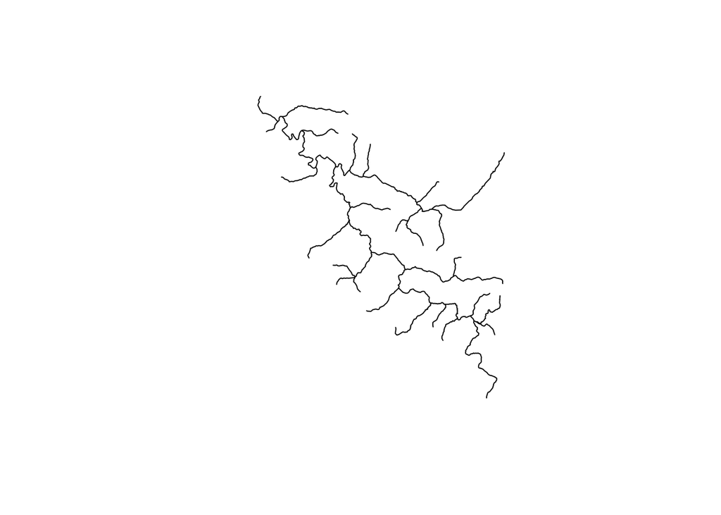

```r
plot(st_geometry(hy))
```

Easy plot function:

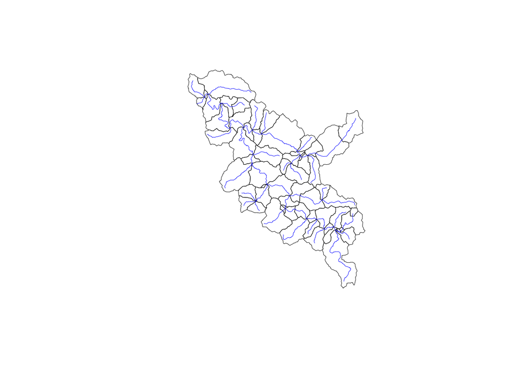

```r
plot_hy(hy)
```

## Modification

Awesome! Now what about “realization” centric calcuations like length/area?

```r
activate(hy, "fl") %>% st_length()
```

```
## Units: [m]
##  [1] 1031.60140 4371.80930 2677.66551 1382.10118 3140.63735 2528.08366
##  [7] 2007.96864 1280.40266 5296.77277 4020.30411 1172.68727 2249.77637
## [13] 3069.92967 3600.46932 4812.27250 2320.63212 2417.54451 4146.96871
## [19] 2884.65096 4443.28529 1131.70074 1915.84163 1899.58681 4467.59818
## [25]  176.12885 2765.35938  581.64953 4785.60500 3293.02729 3603.12722
## [31] 3756.68088  429.93948 3138.89914  326.15959 2683.56520 2381.55804
## [37]  393.03568  641.45321  347.99906 1290.26226 1020.60821 1370.53373
## [43] 1180.76092 3034.96617 1206.78601   81.85666 2033.56527 1194.75186
## [49] 1946.22228 1572.92528  472.82031 2231.81627 1796.95737 2011.85822
## [55] 1614.65199 1408.56060 2444.26365  650.70234 8436.71117 1458.92359
## [61]  269.51700  229.88945
```

```r
activate(hy, "fl") %>% st_area()
```

```
## Units: [m^2]
##  [1] 0 0 0 0 0 0 0 0 0 0 0 0 0 0 0 0 0 0 0 0 0 0 0 0 0 0 0 0 0 0 0 0 0 0 0 0 0 0
## [39] 0 0 0 0 0 0 0 0 0 0 0 0 0 0 0 0 0 0 0 0 0 0 0 0
```

```r
activate(hy, "cat") %>% st_area()
```

```
## Units: [m^2]
##  [1]  1266748.176  5603406.780  3043755.581  1462617.195  4642872.124
##  [6]  3091092.697  3217553.845  3066377.430 12283968.180  3764570.923
## [11]  1301753.592  2083075.448  5645318.799  8784125.684 12545408.736
## [16]  2734979.485  2787901.313  4494868.272  4283265.055  4509269.547
## [21]   942260.122  1955135.309  2225215.457  8258405.175    33720.127
## [26]  7080358.440   260017.106  5960880.726  4216172.948  6932228.872
## [31]  3381544.610  1073292.704  5132383.571   183268.598  3641144.679
## [36]  4088531.073   166707.222   560391.337   248980.607  1538351.690
## [41]  1851024.958  1255532.334   650970.939  3845906.911  1688472.348
## [46]     6894.141  2299653.758   870135.755  1275638.169  1664494.850
## [51]    97775.561  3421212.850  1536479.900  1631053.525  2204811.026
## [56]  2092422.736  3639616.522  1796448.856 11268499.475  1691584.348
## [61]   561517.409   109441.794
```

Flow path should be LINESTRINGS, not MULTILINESTRINGS. Always!

```r
hy = multi_to_line(activate(hy, "fl"))
```

## {Graph}ing

We can also look at “spatial graph” representations of this `hy` object. Here we enforce, a topologic order as well:

```r
hy_net = make_graph(hy)
hy_net
```

```
## # A sfnetwork with 63 nodes and 62 edges
## #
## # CRS:  unknown
## #
## # A rooted tree with spatially explicit edges
## #
## # Node Data:     63 x 2 (active)
## # Geometry type: POINT
## # Dimension:     XY
## # Bounding box:  xmin: -2304058 ymin: 1997144 xmax: -2286676 ymax: 2018649
##              fl_geom topo_order
##          <POINT [m]>      <int>
## 1 (-2297729 2009803)         56
## 2 (-2297659 2010729)         57
## 3 (-2294429 2002169)          1
## 4 (-2291914 2003907)         50
## 5 (-2304058 2018649)          2
## 6 (-2302831 2016868)         62
## # … with 57 more rows
## #
## # Edge Data:     62 x 13
## # Geometry type: LINESTRING
## # Dimension:     XY
## # Bounding box:  xmin: -2304252 ymin: 1997144 xmax: -2286676 ymax: 2018649
##    from    to  comid                  cat_geom fromCOMID tonode fromnode
##   <int> <int>  <int>        <MULTIPOLYGON [m]> <json>     <dbl>    <dbl>
## 1     1     2 5.33e6 (((-2298945 2010285, -22… [5329357… 1.00e7 10016176
## 2     3     4 5.33e6 (((-2293875 2001105, -22… ["NA"]  … 1.00e7 10099101
## 3     5     6 5.33e6 (((-2303625 2016765, -23… ["NA"]  … 1.00e7 10099067
## # … with 59 more rows, and 6 more variables: streamorde <int>,
## #   levelpathi <dbl>, hydroseq <dbl>, fl_geom <LINESTRING [m]>, toCOMID <int>,
## #   lengthkm <dbl>
```